# Predicting Used Car Prices

## Phase 1: Data Preparation and Visualisation

#### Group Name: Project Group 50

#### Name(s) & ID(s) of Group Members: Mohammed Ismail Shareef (S3967638)

- Introduction
  - Dataset Source
  - Dataset Details
  - Dataset Variables
  - Response Variable
- Goals and Objectives
- Data Cleaning and Preprocessing
- Data Exploration and Visualisation
- Summary and Conclusions
- References

## Introduction

### Dataset Source

The data source which was used in this project is the Car Detail from Car Dekho which was sourced from [Kaggle](https://www.kaggle.com/) [(Kaggle. (2019). Kaggle: Your Home for Data Science. Kaggle.com.)](https://www.kaggle.com/). This dataset [(dataset link)](https://www.kaggle.com/datasets/nehalbirla/vehicle-dataset-from-cardekho) contains the prices of 4340 used cars that were sold.

### Dataset Details

This dataset is about the prices of used cars that were sold and their data was collected by CarDekho, an Indian website that is primarily used for buying and selling cars. It dataset contains information about each car that was sold such as the name of the car, the year of manufacture, the kilometres driven, the fuel the car uses, the seller type, the transmission of the car, the type of owner selling the car and most importantly, the price which the car was sold at. This information is adequate to construct a predictive model of used car selling prices as a regressive problem.

This dataset has 8 features and 4340 observations.

```python
import warnings
warnings.filterwarnings("ignore")

import numpy as np
import pandas as pd

pd.set_option('display.max_columns', None)

import matplotlib.pyplot as plt
import seaborn as sns
%matplotlib inline
%config InlineBackend.figure_format = 'retina'
plt.style.use("seaborn")
```

```python
cars_df = pd.read_csv('cars.csv')
```

```python
cars_df.sample(10, random_state=1234)
```

|  | name | year | selling_price | km_driven | fuel | seller_type | transmission | owner |
| --- | --- | --- | --- | --- | --- | --- | --- | --- |
| 3866 | Hyundai Creta 1.6 CRDi SX | 2017 | 1260000 | 39221 | Diesel | Dealer | Manual | First Owner |
| 909 | Maruti S-Cross Zeta DDiS 200 SH | 2015 | 750000 | 45974 | Diesel | Trustmark Dealer | Manual | First Owner |
| 1866 | Mahindra Scorpio 2.6 SLX CRDe | 2006 | 300000 | 120000 | Diesel | Individual | Manual | Second Owner |
| 1532 | Jaguar XF 3.0 Litre S Premium Luxury | 2012 | 1800000 | 50000 | Diesel | Individual | Automatic | Second Owner |
| 1028 | Maruti Ertiga VXI | 2015 | 625000 | 11918 | Petrol | Trustmark Dealer | Manual | First Owner |
| 2803 | BMW X1 sDrive20d | 2012 | 700000 | 120000 | Diesel | Individual | Automatic | Second Owner |
| 445 | Tata Indica Vista Terra 1.4 TDI | 2009 | 150000 | 164000 | Diesel | Individual | Manual | Second Owner |
| 3265 | Maruti Zen LXi - BS III | 2005 | 125000 | 34000 | Petrol | Dealer | Manual | First Owner |
| 1971 | Tata Hexa XT | 2019 | 1100000 | 40000 | Diesel | Individual | Manual | First Owner |
| 3980 | Hyundai Creta 1.6 CRDi SX Option | 2015 | 1025000 | 90000 | Diesel | Individual | Manual | Second Owner |

### Dataset Variables

The variables of the dataset that will be included in the project are displayed below in a table format. This table will describe the following:

- The name of the variable
- Data type (numeric, binary, nominal categorical, ordinal categorical, date)
- Units ("Unknown" or "NA" for Not Applicable are acceptable)
- Brief description

```python
from tabulate import tabulate

table = [['name','Data Type','Units','Description'],
         ['year','Numeric','Years','The year of manufacture of the car'],
         ['selling_price','Numeric','Indian Rupees','The selling price of the car'],
         ['km_driven','Numeric','Kilometers','Number of kilometers car driven at point of sale'],
         ['fuel','Nominal Categorical','NA','Type of fuel the car uses'],
         ['seller_type','Nominal Categorical','NA','The seller type (individual, dealer, trustmark dealer)'],
         ['transmission','Nominal Categorical','NA','The transmission of the car (automatic, manual)'],
         ['owner','Nominal Categorical','NA','Which owner has sold the car (first, second, etc.)']
        ]

print(tabulate(table, headers='firstrow', tablefmt='fancy_grid'))
```

```
╒═══════════════╤═════════════════════╤═══════════════╤════════════════════════════════════════════════════════╕
│ name          │ Data Type           │ Units         │ Description                                            │
╞═══════════════╪═════════════════════╪═══════════════╪════════════════════════════════════════════════════════╡
│ year          │ Numeric             │ Years         │ The year of manufacture of the car                     │
├───────────────┼─────────────────────┼───────────────┼────────────────────────────────────────────────────────┤
│ selling_price │ Numeric             │ Indian Rupees │ The selling price of the car                           │
├───────────────┼─────────────────────┼───────────────┼────────────────────────────────────────────────────────┤
│ km_driven     │ Numeric             │ Kilometers    │ Number of kilometers car driven at point of sale       │
├───────────────┼─────────────────────┼───────────────┼────────────────────────────────────────────────────────┤
│ fuel          │ Nominal Categorical │ NA            │ Type of fuel the car uses                              │
├───────────────┼─────────────────────┼───────────────┼────────────────────────────────────────────────────────┤
│ seller_type   │ Nominal Categorical │ NA            │ The seller type (individual, dealer, trustmark dealer) │
├───────────────┼─────────────────────┼───────────────┼────────────────────────────────────────────────────────┤
│ transmission  │ Nominal Categorical │ NA            │ The transmission of the car (automatic, manual)        │
├───────────────┼─────────────────────┼───────────────┼────────────────────────────────────────────────────────┤
│ owner         │ Nominal Categorical │ NA            │ Which owner has sold the car (first, second, etc.)     │
╘═══════════════╧═════════════════════╧═══════════════╧════════════════════════════════════════════════════════╛
```

- [Akman, D. D. (2022, March 22). OpenIntro Labs for Python. GitHub. https://github.com/akmand/stats_tutorials/blob/main/Phase1_Report_Sample.ipynb](https://github.com/akmand/stats_tutorials/blob/main/Phase1_Report_Sample.ipynb)

### Response Variable

In this project, the response variable will be the selling price of the car sold in Indian Rupees. This selling price of the car sold in Indian Rupees will be predicted on the basis of the explanatory variables such as the number of kilometers that the car has driven, the year of manufacture of the car, the transmission and the other features that were also described in the table above.

### Goals and Objectives

The car market in India has been growing for the last few decades. In particular, the used car market in India has been said to grow at a compounded annual growth rate of 11%, and has been predicted to reach sales of up to 8.3 million by the financial year of 2026. In relation to this, online car marketplaces, one being CarDekho as presented in this project, have become highly popularised. Therefore, by analysing the data collected from CarDekho through a model that can predict a used cars selling price can help greatly in the real world. Car dealerships as well as individuals who want to sell their car(s) or may want to sell them sometime in the future can use the predicted selling prices to help them with their financial planning such as factoring in the predicted amount of money that they would receive from selling their car(s). Furthermore, individuals may use the predicted data to help them sell their car at the right price and avoid being underpaid for their car.

The objective of this project is to predict the selling price of used cars based on the information about the car such as the make, the number of kilometers it was driven when it was sold, the transmission of the car and so on. This will ultimately aid car dealerships as well as individuals who want to sell their used car(s).

### Data Cleaning and Preprocessing

The columns of the dataset for the sales of the used cars as recorded by CarDekho are listed below:

```python
cars_df.columns
```

```
Index(['name', 'year', 'selling_price', 'km_driven', 'fuel', 'seller_type',
       'transmission', 'owner'],
      dtype='object')
```

From the columns listed above, it can be said that there are no two columns which are similar to each other, that is, each column is a unique attribute of the dataset and hence, there is no need to drop any of the columns at this point in time.

Furthermore, all of the column heading are in lower case and there are no white spaces present, hence there is no change that is needed to be made to any of the column headings.

```python
cars_df.isnull().sum()
```

```
name             0
year             0
selling_price    0
km_driven        0
fuel             0
seller_type      0
transmission     0
owner            0
dtype: int64
```

From the data above, none of the attributes of the dataset (the columns) have a null value, so no further action has to be taken to fill in missing values or drop the rows with missing rows.

```python
cars_df.shape[0]
```

```
4340
```

As seen above, the dataset as 4340 rows, so in this project all 4340 sales of used cars will be used to make predictions.

However, the name column contains the make of the car as well the model of the car, however, in order to clean this data since there might be naming errors within the format of the model part of the names attribute, the model part will be dropped and only the name of the manufacturer of the car will remain so that accurate modeling may be conducted and car manufacturers, car dealerships and individuals may see the general results of the selling price of each car brand rather than the car brand as well as it's specific model.

The code below splits the name attribute of the cars dataframe so that only the brand of the car is stored and the model of the car is discarded.

```python
cars_df['name'] = cars_df.name.str.split().str.get(0)
```

```python
cars_df.head(5)
```

|  | name | year | selling_price | km_driven | fuel | seller_type | transmission | owner |
| --- | --- | --- | --- | --- | --- | --- | --- | --- |
| 0 | Maruti | 2007 | 60000 | 70000 | Petrol | Individual | Manual | First Owner |
| 1 | Maruti | 2007 | 135000 | 50000 | Petrol | Individual | Manual | First Owner |
| 2 | Hyundai | 2012 | 600000 | 100000 | Diesel | Individual | Manual | First Owner |
| 3 | Datsun | 2017 | 250000 | 46000 | Petrol | Individual | Manual | First Owner |
| 4 | Honda | 2014 | 450000 | 141000 | Diesel | Individual | Manual | Second Owner |

As seen in the table above, only the brand of the car is stored as the name. (The model of the car was dropped).

#### The data is now clean and ready to be used for visualisation and exploration

### Data Exploration and Visualisation

#### One-Variable Plot Visualisation

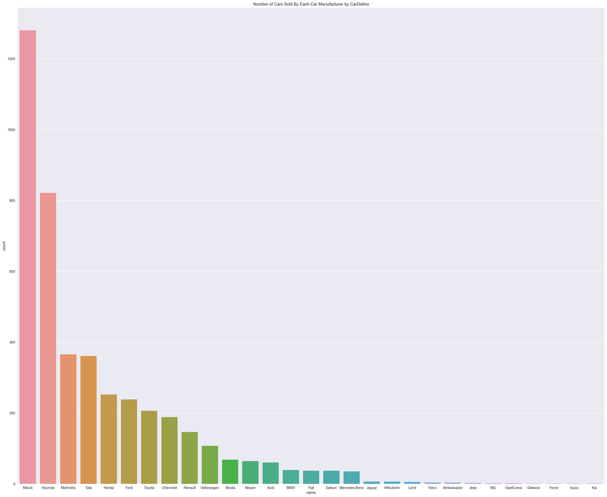

```python
plt.figure(figsize = (30,25))
fig = sns.countplot(x = 'name', data = cars_df, order = cars_df['name'].value_counts().index)
fig = plt.title('Number of Cars Sold By Each Car Manufacturer by CarDekho')
plt.show()
```

From the data presented above, the brand of the used car that is least sold by one the of the leading online car marketplace in India, CarDekho, is Kia. On the other hand however, the brand of the used car that was most sold is Maruti, which is an Indian owned automotive company. Since this car brand Maruti is an Indian automotive company, it might perhaps explain why it's used cars are the most sold in India. This will be researched further in the phase 2 of this project.

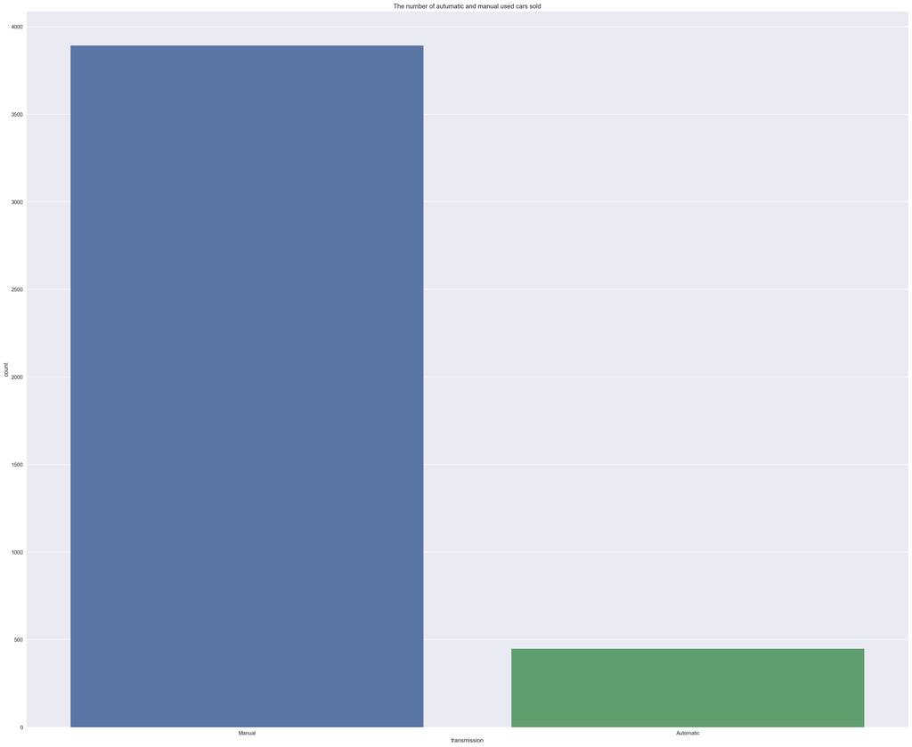

```python
plt.figure(figsize = (30,25))
fig = sns.countplot(x = 'transmission', data = cars_df, order = cars_df['transmission'].value_counts().index)
fig = plt.title('The number of autumatic and manual used cars sold')
plt.show()
```

The number of used cars through the online marketplace CarDekho which had a manual transmission were far greater in number than the number of used cars which had an automatic transmission. This will be further explored by analysing whether the transmission of the car may have had an impact upon the selling price of the car.

### Two-Variable Plot Visualisation

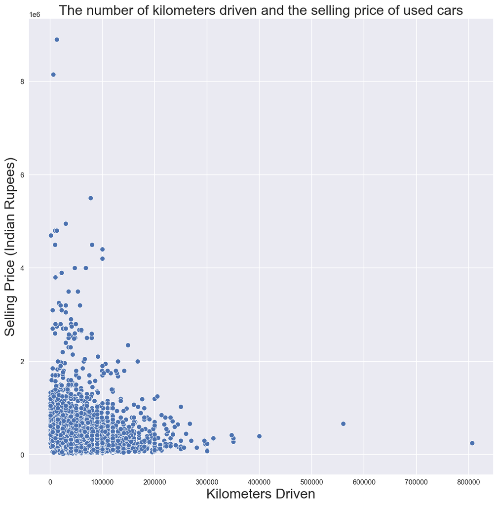

```python
plt.figure(figsize = (30,25))
fig = sns.relplot(x="km_driven", y="selling_price",height=10, data=cars_df);
fig = plt.title('The number of kilometers driven and the selling price of used cars', fontsize = 20)
plt.xlabel("Kilometers Driven", fontsize = 20)
plt.ylabel("Selling Price (Indian Rupees)", fontsize = 20)
plt.show()
```

From the scatterplot above, it can be analysed and said that a correlation is present between the number of kilometers has driven the selling price of the car. From the graph above, as the number of kilometers increases, the selling price of the car decreases.

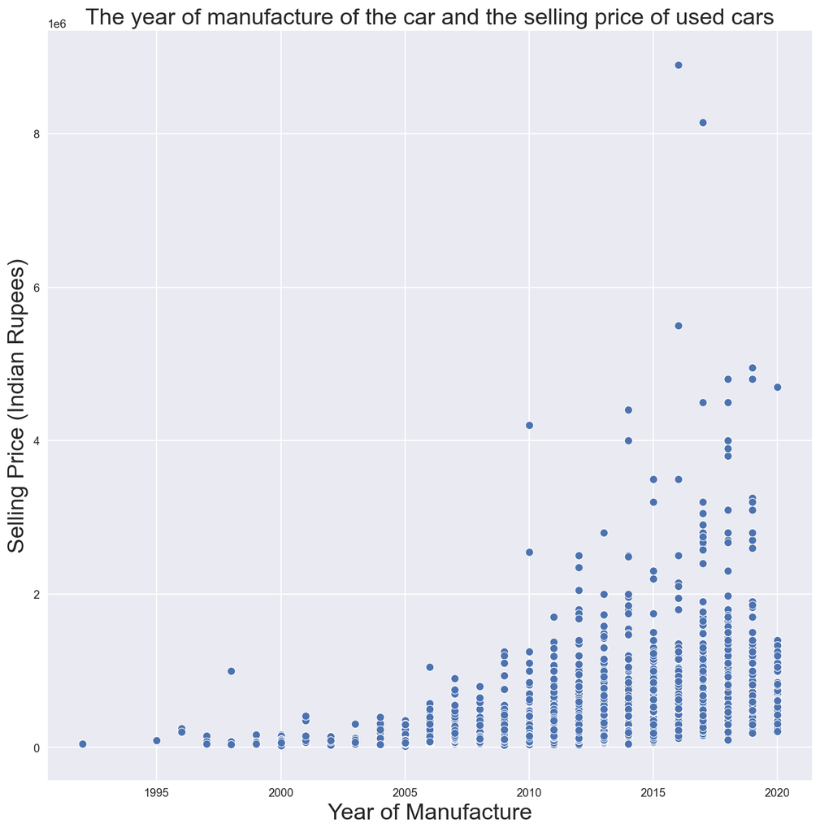

```python
plt.figure(figsize = (30,25))
fig = sns.relplot(x="year", y="selling_price",height=10, data=cars_df);
fig = plt.title('The year of manufacture of the car and the selling price of used cars', fontsize = 20)
plt.xlabel("Year of Manufacture", fontsize = 20)
plt.ylabel("Selling Price (Indian Rupees)", fontsize = 20)
plt.show()
```

From the scatterplot above, it can be analysed and said that a correlation is present between the year of manufacture of the used car and the selling price of the used car. As seen in the graph above, it is quite apparent that as the year of manufacture of the car increases, that is, the used car is newer, the price of the car also significantly increases, however, there are some exceptions such as some of the cars with an older year of manufacture still having a high selling price. This correlation does not however, highlight a causation, this is because newer cars usually have less kilometers drive than older cars, and the newer car brands are possibly to those cars which are older.